# CloverHealth

```python
import numpy as np
import pandas as pd
import warnings
warnings.filterwarnings('ignore')

import matplotlib.pyplot as plt
import seaborn as sns

from sklearn.model_selection import train_test_split, GridSearchCV
from sklearn.linear_model import LogisticRegression
from sklearn.metrics import roc_auc_score, roc_curve

pd.set_option('display.max_columns', 500)
```

```python
medic = pd.read_csv('Downloads/meps_meds.csv').iloc[:, 1:]
patient = pd.read_csv('Downloads/meps_base_data.csv').iloc[:,1:]
```

```python
print(medic.isnull().sum())
print(patient.isnull().sum())
```

```
id              0
rxStartMonth    0
rxStartYear     0
rxName          0
rxNDC           0
rxQuantity      0
rxForm          0
dtype: int64
id                       0
panel                    0
pooledWeight             0
age                      0
sex                      0
race                     0
married                  0
highBPDiagnosed          0
diabetesDiagnosed        0
chdDiagnosed             0
miDiagnosed              0
anginaDiagnosed          0
strokeDiagnosed          0
emphysemaDiagnosed       0
asthmaDiagnosed          0
otherHDDiagnosed         0
heartFailureDiagnosed    0
dtype: int64
```

```python
patient.head(5)
```

|  | id | panel | pooledWeight | age | sex | race | married | highBPDiagnosed | diabetesDiagnosed | chdDiagnosed | miDiagnosed | anginaDiagnosed | strokeDiagnosed | emphysemaDiagnosed | asthmaDiagnosed | otherHDDiagnosed | heartFailureDiagnosed |
| --- | --- | --- | --- | --- | --- | --- | --- | --- | --- | --- | --- | --- | --- | --- | --- | --- | --- |
| 0 | 10007101 | 15 | 3603.881236 | 28 | Male | White | MARRIED | Yes | No | No | No | No | No | No | No | No | No |
| 1 | 10007102 | 15 | 2544.550424 | 25 | Female | White | MARRIED | No | No | No | No | No | No | No | Yes | No | No |
| 2 | 10007103 | 15 | 4050.397468 | 4 | Male | White | UNDER 16 - INAPPLICABLE | Inapplicable | Inapplicable | Inapplicable | Inapplicable | Inapplicable | Inapplicable | Inapplicable | No | Inapplicable | No |
| 3 | 10007104 | 15 | 3064.059720 | 3 | Female | White | UNDER 16 - INAPPLICABLE | Inapplicable | Inapplicable | Inapplicable | Inapplicable | Inapplicable | Inapplicable | Inapplicable | No | Inapplicable | No |
| 4 | 10008101 | 15 | 3635.552466 | 51 | Male | Multiple | MARRIED | No | No | No | No | No | No | No | No | No | No |

```python
data = medic.merge(patient, how= 'left', on = 'id')
```

```python
data.shape
```

```
(1148347, 23)
```

LISINOPRIL, METFORMIN and SIMVASTATIN are the most common medications with over 1 million doses prescribed.

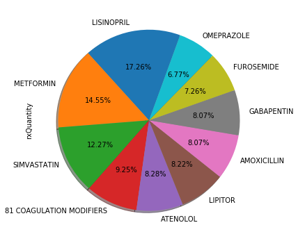

```python
f, ax = plt.subplots(1,1, figsize=(16,6))

top_meds = data.groupby('rxName')['rxQuantity'].sum().nlargest(10)
top_meds.plot.pie( autopct='%1.2f%%', ax=ax, shadow=True, labels= top_meds.index, fontsize=10, startangle=70)
```

```python
diseases = ['highBP', 'diabetes', 'chd', 'mi', 'angina', 'stroke', 'emphysema',
            'asthma', 'otherHD', 'heartFailure']

top_meds_list = []

for disease in diseases:
    top_medications = data[data[disease + 'Diagnosed'] == 'Yes'].groupby(['rxName'])['id'].count().nlargest(1)
    #top_meds_quantity = data[data[disease + 'Diagnosed'] == 'Yes'].groupby(['rxName'])['rxQuantity'].sum().nlargest(1)
    top_meds_list.append(top_medications)
    #top_meds_list.append(top_meds_quantity)
df_meds = pd.concat(top_meds_list)
```

```python
top_df = pd.concat([pd.Series(diseases, name = 'disease'), df_meds.reset_index()], axis = 1)
```

High blood pressure patients take a high amount of ISINOPRIL - around 1.5 million grams.

ISINOPRIL is the top choice of medication for 7 out of 10 diseases in the dataset. This is because ISINOPRIL is the first line of medications and is used to treat high blood pressure, heart failure, and strokes.

Diabetes patients take a high amount of METFORMIN - around 1.3 million grams.

Albuterol is top choice of medications for asthma.

```python
top_df
```

|  | disease | rxName | id |
| --- | --- | --- | --- |
| 0 | highBP | LISINOPRIL | 30607 |
| 1 | diabetes | METFORMIN | 13259 |
| 2 | chd | LISINOPRIL | 6461 |
| 3 | mi | LISINOPRIL | 4749 |
| 4 | angina | LISINOPRIL | 2847 |
| 5 | stroke | LISINOPRIL | 3683 |
| 6 | emphysema | LISINOPRIL | 2005 |
| 7 | asthma | ALBUTEROL | 5595 |
| 8 | otherHD | LISINOPRIL | 7785 |
| 9 | heartFailure | FUROSEMIDE | 2841 |

Let's take a look at most indicative medications for each disease. The most common medications might not be the most indicative ones. For example, aspirins is prescribed to treat high blood pressure, but not all people who take aspirins have high blood pressure.

```python
largest_list = []
second_largest = []

for med in data[data.rxName != '81 COAGULATION MODIFIERS'].groupby('rxName')['rxQuantity'].sum().nlargest(10).index:
    percent_list = []

    for disease in diseases:
        g = data[data.rxName == med].groupby(['rxName',
                                           disease + 'Diagnosed'])['rxQuantity'].sum()
        df = pd.DataFrame(g.groupby(level = 0).apply(lambda x: x/x.sum()).reset_index()).reset_index(drop=True)

        percent = df[df[ disease + 'Diagnosed'] == 'Yes']['rxQuantity'].values[0]
        percent_list.append(percent)

    largest_percent = max(percent_list)
    index = percent_list.index(largest_percent)
    largest_list.append(int(largest_percent * 100))

    #new_list = percent_list.remove(largest_percent)
    #second_largest = max(new_list)
    #index_2 = new_list.index(second_largest)
    #second_largest_list.append(int(second_largest * 100))

pd.concat([pd.Series(data.groupby('rxName')['rxQuantity'].sum().nlargest(10).index, name = 'meds'),
           pd.Series(diseases, name = 'disease_1'), pd.Series(largest_list, name = 'percent_1'),
           #pd.Series(diseases, name = 'disease_2'), pd.Series(second_largest_list, name = 'percent_2'),
          ], axis = 1)
```

|  | meds | disease_1 | percent_1 |
| --- | --- | --- | --- |
| 0 | LISINOPRIL | highBP | 90 |
| 1 | METFORMIN | diabetes | 90 |
| 2 | SIMVASTATIN | chd | 74 |
| 3 | 81 COAGULATION MODIFIERS | mi | 92 |
| 4 | ATENOLOL | angina | 71 |
| 5 | LIPITOR | stroke | 12 |
| 6 | AMOXICILLIN | emphysema | 67 |
| 7 | GABAPENTIN | asthma | 85 |
| 8 | FUROSEMIDE | otherHD | 71 |
| 9 | OMEPRAZOLE | heartFailure | 68 |

The table shows for each disease, the percentage of patient who take the medications have the disease.

Keep in mind that it is important to look at the total raw numbers when we are deciding the most indicative medication for each disease. For example, we will not be gaining much information knowing that 10 people take X drugs and all 10 of them, which is 100%, have disease A since the sample size is too small.

Earlier analysis shows that LISINOPRIL is the most common drugs for 7 diseases on the list, but LISINOPRIL is the most indicative of high blood pressure - 86% of LISINOPRIL takers have LISINOPRIL

```python
for disease in diseases:
    print('**' + disease)
    count_list = []
    percent_list = []
    top_meds = data[data[disease + 'Diagnosed'] == 'Yes'].groupby('rxName')['rxQuantity'].sum().nlargest(5)
    for med in top_meds.index:
        g = data[data.rxName == med].groupby([disease + 'Diagnosed'])['id'].nunique()
        count = g.reset_index()
        b = count[count[disease + 'Diagnosed'] == 'Yes']['id'].values[0]
        count_list.append(b)
        calc_percent = (g/g.sum() * 100).astype(int).reset_index()
        a = calc_percent[calc_percent[disease + 'Diagnosed'] == 'Yes']['id'].values[0]

        percent_list.append(a)

    df = pd.concat( [pd.Series(top_meds.index, name = 'meds'),
                     pd.Series(count_list, name = 'count'),
                     pd.Series(percent_list, name = 'percent')], axis = 1)
    print(df)
```

```
**highBP
          meds  count  percent
0   LISINOPRIL   2996       86
1    METFORMIN   1322       71
2  SIMVASTATIN   2184       70
3     ATENOLOL   1219       88
4   FUROSEMIDE   1167       82
**diabetes
          meds  count  percent
0    METFORMIN   1543       83
1   LISINOPRIL   1214       35
2    GLYBURIDE    464       90
3    GLIPIZIDE    559       93
4  SIMVASTATIN   1019       32
**chd
```

[output cut: 55 more lines]

Since my relatives have background of diabetes, I am going to build a model to detect diabetes patients. We know from earlier that diabetes patients take METFORMIN , GLIPIZIDE, GLYBURIDE, FUROSEMIDE and ENSURE. We are going to aggregate the data on the patient level and do some feature engineering.

```python
#most common meds for diabetes
METFORMIN = medic[medic.rxName == 'METFORMIN'].groupby('id')['rxQuantity'].count().reset_index().rename(columns = {'rxQuantity': 'METFORMIN'})
#most indicative meds
GLIPIZIDE = medic[medic.rxName == 'GLIPIZIDE'].groupby('id')['rxQuantity'].count().reset_index().rename(columns = {'rxQuantity': 'GLIPIZIDE'})
GLYBURIDE = medic[medic.rxName == 'GLYBURIDE'].groupby('id')['rxQuantity'].count().reset_index().rename(columns = {'rxQuantity': 'GLYBURIDE'})
FUROSEMIDE = medic[medic.rxName == 'FUROSEMIDE'].groupby('id')['rxQuantity'].count().reset_index().rename(columns = {'rxQuantity': 'FUROSEMIDE'})
ENSURE = medic[medic.rxName == 'ENSURE'].groupby('id')['rxQuantity'].count().reset_index().rename(columns = {'rxQuantity': 'ENSURE'})
```

```python
columns = ['id', 'age', 'sex', 'married', 'diabetesDiagnosed']
dia = patient[columns].merge(METFORMIN, how = 'left', on = 'id')
dia = dia.merge(GLIPIZIDE, how = 'left', on = 'id')
dia = dia.merge(GLYBURIDE, how = 'left', on = 'id')
dia = dia.merge(FUROSEMIDE, how = 'left', on = 'id')
dia = dia.merge(ENSURE, how = 'left', on = 'id')

dia['METFORMIN'] = np.where(pd.isnull(dia['METFORMIN']), 0, 1)
dia['GLIPIZIDE'] = np.where(pd.isnull(dia['GLIPIZIDE']), 0, 1)
dia['GLYBURIDE'] = np.where(pd.isnull(dia['GLYBURIDE']), 0, 1)
dia['FUROSEMIDE'] = np.where(pd.isnull(dia['FUROSEMIDE']), 0, 1)
dia['ENSURE'] = np.where(pd.isnull(dia['ENSURE']), 0, 1)
```

```python
diabetes_count = dia['diabetesDiagnosed'].value_counts()
print(diabetes_count)
print(diabetes_count/diabetes_count.sum()* 100)
```

```
No                 38848
Inapplicable       18270
Yes                 4340
DK                    19
not ascertained        7
Refused                5
Name: diabetesDiagnosed, dtype: int64
No                 63.178780
Inapplicable       29.712632
Yes                 7.058173
DK                  0.030900
not ascertained     0.011384
Refused             0.008132
Name: diabetesDiagnosed, dtype: float64
```

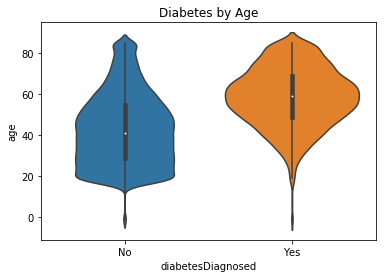

```python
fig, ax = plt.subplots(1, 1, figsize = (6, 4))
diaa = dia[(dia.diabetesDiagnosed == 'Yes') | (dia.diabetesDiagnosed == 'No')].reset_index()
sns.violinplot(x = 'diabetesDiagnosed', y = 'age', data = diaa )
ax.set_title('Diabetes by Age')
```

```python
data.groupby(['diabetesDiagnosed'])['age'].mean()
```

```
diabetesDiagnosed
DK                 78.248619
Inapplicable        8.251114
No                 55.922705
Refused            56.000000
Yes                61.463745
not ascertained    35.307692
Name: age, dtype: float64
```

```python
def age_bucket(age):
    if (age>=0)  & (age < 18):
        return 'child'
    elif (age >= 18) & (age <= 30):
        return 'young_adult'
    elif (age > 30) &  (age <= 65):
        return 'adult'
    elif age >= 65:
        return 'older'

diaa['age_group'] = diaa['age'].apply(age_bucket)
```

```
age_group    diabetesDiagnosed
adult        No                   23158
             Yes                   2808
child        No                     886
             Yes                      7
older        No                    4565
             Yes                   1414
young_adult  No                   10137
             Yes                    103
Name: id, dtype: int64
```

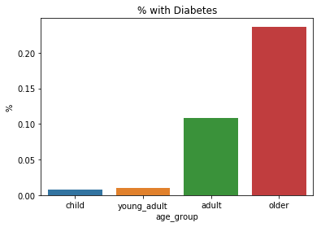

```python
g = diaa.groupby(['age_group', 'diabetesDiagnosed'])['id'].count()
print(g)
age_percent = g.groupby(level = 0).apply(lambda x: x/x.sum())[1::2].reset_index()
age_percent
ax = sns.barplot(x = 'age_group', y = 'id', data = age_percent, order = ['child', 'young_adult', 'adult', 'older'])
ax.set_title('% with Diabetes')
ax.set_ylabel('%')
```

```python
g = diaa.groupby(['sex', 'diabetesDiagnosed'])['id'].count()
print(g)
print(g.groupby(level=0).apply(lambda x: x/x.sum()))
```

```
sex     diabetesDiagnosed
Female  No                   20805
        Yes                   2402
Male    No                   18043
        Yes                   1938
Name: id, dtype: int64
sex     diabetesDiagnosed
Female  No                   0.896497
        Yes                  0.103503
Male    No                   0.903008
        Yes                  0.096992
Name: id, dtype: float64
```

Female has a slightly higher chance of getting diabetes.

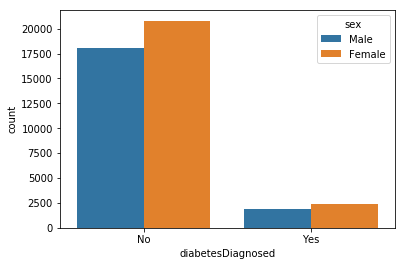

```python
sns.countplot(x = 'diabetesDiagnosed', hue = 'sex', data = diaa )
```

The distribution of age for male/female and diabetes/non-diabetes groups look similar.

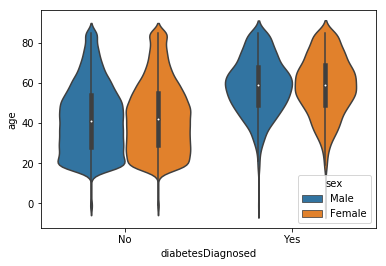

```python
sns.violinplot(x = 'diabetesDiagnosed' , y = 'age',hue = 'sex', data = diaa)
```

```python
def married_status(status):
    if status == 'MARRIED' or status == 'MARRIED IN ROUND':
        return 'MARRIED'
    elif status == 'DIVORCED' or status == 'DIVORCED IN ROUND' or status == 'SEPARATED' or status == 'SEPARATED IN ROUND':
        return 'DIVORCED'
    elif status == 'WIDOWED' or status == 'WIDOWED IN ROUND':
        return 'WIDOWED'
    else:
        return 'NEVER MARRIED'

diaa['married_status'] = diaa['married'].apply(married_status)
```

Age and marrital status is somehow correlated. Patients who have had widowed are the most likely to have diabetes because they tend to be older, which put them at higher risk of diabetes. Patients who have never had married tend to be younger and less likely to have diabetes.

```python
g = diaa.groupby(['married_status', 'diabetesDiagnosed'])['id'].count()
print(g)
g.groupby(level = 0).apply(lambda x: x/x.sum()* 100).reset_index()[1::2]
```

```
married_status  diabetesDiagnosed
DIVORCED        No                    4910
                Yes                    789
MARRIED         No                   20000
                Yes                   2377
NEVER MARRIED   No                   11977
                Yes                    507
WIDOWED         No                    1961
                Yes                    667
Name: id, dtype: int64
```

|  | married_status | diabetesDiagnosed | id |
| --- | --- | --- | --- |
| 1 | DIVORCED | Yes | 13.844534 |
| 3 | MARRIED | Yes | 10.622514 |
| 5 | NEVER MARRIED | Yes | 4.061198 |
| 7 | WIDOWED | Yes | 25.380518 |

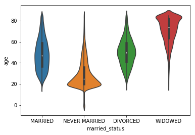

```python
sns.violinplot(x = 'married_status', y = 'age', data = diaa)
```

```python
diaa['DIABETES'] = np.where(diaa['diabetesDiagnosed'] == 'Yes', 1, 0)
diaa['FEMALE'] = np.where(diaa['sex'] == 'Female', 1, 0)
```

[output not shown]

```python
married_df = pd.get_dummies(diaa['married_status'])
diaa = pd.concat([diaa,married_df], axis = 1 )
```

```python
X = diaa[['age', 'FEMALE', 'DIVORCED', 'NEVER MARRIED', 'WIDOWED','METFORMIN', 'GLIPIZIDE', 'GLYBURIDE', 'FUROSEMIDE', 'ENSURE']]
y = diaa['DIABETES']
```

```python
X_train, X_test, y_train, y_test = train_test_split(X, y, test_size = 0.2, random_state = 42)
```

```python
rf = RandomForestClassifier(random_state=0)
rf.fit(X_train, y_train)
y_scores = rf.predict_proba(X_test)[:,1]

print('Accuracy:{}'.format( rf.score(X_test, y_test)))
print('AUC:{}'.format( roc_auc_score(y_test, y_scores)))
```

```
Accuracy:0.9393378096781663
AUC:0.8295569080358471
```

```python
clf = LogisticRegression(random_state=0)
clf.fit(X_train, y_train)
y_scores = clf.predict_proba(X_test)[:,1]
print('Accuracy:{}'.format( clf.score(X_test, y_test)))

print('AUC:{}'.format( roc_auc_score(y_test, y_scores)))
```

```
Accuracy:0.9425793007640657
AUC:0.8624171395840786
```

Using accuracy score might not be a good metrics since we have an inbalanced dataset with only 7% of patients that are diabetes positive. We are instead using area under curve as a metrics

```python
print(X.columns)
print(clf.coef_)
```

```
Index(['age', 'FEMALE', 'DIVORCED', 'NEVER MARRIED', 'WIDOWED', 'METFORMIN',
       'GLIPIZIDE', 'GLYBURIDE', 'FUROSEMIDE', 'ENSURE'],
      dtype='object')
[[ 0.03923842 -0.03419147  0.32164693 -0.10634635  0.20246899  4.02841938
   4.12721684  4.04699373  1.24870049  1.25337327]]
```

GLIPIZIDE, GLYBURIDE and METFORMI are highly indicative of diabetes patients. FUROSEMIDE and ENSURE are mildly indicative of diabetes.

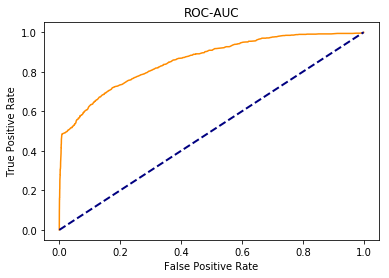

```python
fpr, tpr, thresholds = roc_curve(y_test, y_scores)
plt.plot(fpr, tpr, color = 'darkorange')
plt.plot([0, 1], [0, 1], color='navy', lw=2, linestyle='--')
plt.title('ROC-AUC')
plt.xlabel('False Positive Rate')
plt.ylabel('True Positive Rate')
```

```python
from sklearn.metrics import confusion_matrix
threshold = 0.5
predicted = (clf.predict_proba(X_test)[:,1] >= threshold).astype('int')

tn, fp, fn, tp = confusion_matrix( y_test, predicted).ravel()

recall = tp/(fp + tp)
precision = tp/ (tp + fn)
print('Precision:{}'.format(recall))
print('Recall:{}'.format(precision))
```

```
Precision:0.8611111111111112
Recall:0.4832134292565947
```

Precision: Out of all the ones predicted positive, 86% of them actually have diabetes. Recall: Out of all the ones actually positive, we predicted 48% of them have diabetes.

The modeltells us that whether the patients take GLIPIZIDE, GLYBURIDE or METFORMI is highly indicative of diabetes patients. FUROSEMIDE and ENSURE are also mildly indicative of diabetes. Besides medications, variables including age, sex and marrital status, are included in the model as well.